# ASURAT

### 4.2.3 Remove variables based on the mean read counts

Qualities of variable (gene) data are confirmed based on proper visualization of `rowData(sce)`. ASURAT function `plot_dataframe2D()` shows scatter plots of two-dimensional data. See `?plot_dataframe2D` for details.

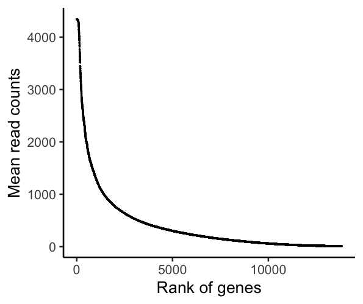

```r
dataframe2D <- data.frame(x = 1:nrow(rowData(pbmc)),
                          y = sort(rowData(pbmc)$nSamples, decreasing = TRUE))
plot_dataframe2D(dataframe2D = dataframe2D) +
  ggplot2::labs(x = "Rank of genes", y = "Mean read counts") +
  ggplot2::theme_classic(base_size = 20)
```

ASURAT function `remove_variables_second()` removes variable (gene) data such that the mean read counts across samples are less than `min_meannReads`.

```r
pbmc <- remove_variables_second(sce = pbmc, min_meannReads = 0.05)
```

## 4.3 Normalize data

Normalize data using log transformation with a pseudo count and center the data by subtracting with the mean expression levels across samples (cells). The resulting normalized-and-centered data are used for downstream analyses.

Perform log-normalization with a pseudo count.

```r
assay(pbmc, "logcounts") <- log(assay(pbmc, "counts") + 1)
```

Center each row data.

```r
mat <- assay(pbmc, "logcounts")
assay(pbmc, "centered") <- sweep(mat, 1, apply(mat, 1, mean), FUN = "-")
```

# 5 Multifaceted sign analysis

Infer cell or disease types, biological functions, and signaling pathway activity at the single-cell level by inputting related databases.

ASURAT transforms centered read count tables to functional feature matrices, termed sign-by-sample matrices (SSMs). Using SSMs, perform unsupervised clustering of samples (cells).

## 5.1 Load databases

Load databases.

```r
urlpath <- "https://github.com/keita-iida/ASURATDB/blob/main/genes2bioterm/"
load(url(paste0(urlpath, "20220108_human_COMSig.rda?raw=TRUE"))) # CO & MSigDB
load(url(paste0(urlpath, "20201213_human_GO_red.rda?raw=TRUE"))) # GO
load(url(paste0(urlpath, "20201213_human_KEGG.rda?raw=TRUE")))   # KEGG
```

The reformatted knowledge-based data were available from the following repositories:

- [DOI:10.6084/m9.figshare.19102598](https://figshare.com/s/0599d2de970c2deb675c)
- [Github ASURATDB](https://github.com/keita-iida/ASURATDB)

Prepare a correlation matrix of gene expressions using random sampling for the fast computation.

```r
set.seed(1)
nrand_samples <- 1000
mat <- t(as.matrix(assay(pbmc, "centered")))
ids <- sample(rownames(mat), nrand_samples, prob = NULL)
pbmc_cormat <- cor(mat[ids, ], method = "spearman")
```

Set gene expression data into `altExp(sce)`.

**Tips:** Take care not to use a slot name “log-normalized” for `altExp(sce)`, which may produce an error when using a Seurat (version 4.0.5) function `as.Seurat()` in the downstream analysis.

```r
sname <- "logcounts"
altExp(pbmc, sname) <- SummarizedExperiment(list(counts = assay(pbmc, sname)))
```

Add ENTREZ Gene IDs to `rowData(sce)`.

```r
dictionary <- AnnotationDbi::select(org.Hs.eg.db::org.Hs.eg.db,
                                    key = rownames(pbmc),
                                    columns = "ENTREZID", keytype = "SYMBOL")
dictionary <- dictionary[!duplicated(dictionary$SYMBOL), ]
rowData(pbmc)$geneID <- dictionary$ENTREZID
```

Add formatted databases to `metadata(sce)$sign`.

```r
pbmcs <- list(CM = pbmc, GO = pbmc, KG = pbmc)
metadata(pbmcs$CM) <- list(sign = human_COMSig[["cell"]])
metadata(pbmcs$GO) <- list(sign = human_GO[["BP"]])
metadata(pbmcs$KG) <- list(sign = human_KEGG[["pathway"]])
```

## 5.2 Create signs

ASURAT function `remove_signs()` redefines functional gene sets for the input database by removing genes, which are not included in `rownames(sce)`, and further removes biological terms including too few or too many genes.

The arguments are

- `sce`: SingleCellExperiment object,
- `min_ngenes`: minimal number of genes> 1 (the default value is 2), and
- `max_ngenes`: maximal number of genes> 1 (the default value is 1000).

```r
pbmcs$CM <- remove_signs(sce = pbmcs$CM, min_ngenes = 2, max_ngenes = 1000)
pbmcs$GO <- remove_signs(sce = pbmcs$GO, min_ngenes = 2, max_ngenes = 1000)
pbmcs$KG <- remove_signs(sce = pbmcs$KG, min_ngenes = 2, max_ngenes = 1000)
```

The results are stored in `metadata(sce)$sign`.

The arguments are

- `sce`: SingleCellExperiment object,
- `cormat`: correlation matrix of gene expressions,
- `th_posi` and `th_nega`: threshold values of positive and negative correlation coefficients, respectively.

**Tips:** Empirically, typical values of `th_posi` and `th_nega` are $0.15 \le {\rm th{\_}posi} \le 0.4$ and $-0.4 \le {\rm th{\_}nega} \le -0.15$, but one cannot avoid trial and error for setting these values. An exhaustive parameter searching is time-consuming but helpful for obtaining interpretable results.

```r
set.seed(1)
pbmcs$CM <- cluster_genesets(sce = pbmcs$CM, cormat = pbmc_cormat,
                             th_posi = 0.30, th_nega = -0.30)
set.seed(1)
pbmcs$GO <- cluster_genesets(sce = pbmcs$GO, cormat = pbmc_cormat,
                             th_posi = 0.30, th_nega = -0.30)
set.seed(1)
pbmcs$KG <- cluster_genesets(sce = pbmcs$KG, cormat = pbmc_cormat,
                             th_posi = 0.20, th_nega = -0.20)
```

The results are stored in `metadata(sce)$sign`.

ASURAT function `create_signs()` creates signs by the following criteria:

1. the number of genes in SCG>= `min_cnt_strg` (the default value is 2) and
2. the number of genes in VCG>= `min_cnt_vari` (the default value is 2),

which are independently applied to SCGs and VCGs, respectively.

**Tips:** Empirically, typical values of `min_cnt_strg` and `min_cnt_vari` are $2 \le {\rm min\_cnt\_strg} = {\rm min\_cnt\_vari} \le 3$, but one cannot avoid trial and error for setting these values. An exhaustive parameter searching is time-consuming but helpful for obtaining interpretable results.

```r
pbmcs$CM <- create_signs(sce = pbmcs$CM, min_cnt_strg = 2, min_cnt_vari = 2)
pbmcs$GO <- create_signs(sce = pbmcs$GO, min_cnt_strg = 3, min_cnt_vari = 3)
pbmcs$KG <- create_signs(sce = pbmcs$KG, min_cnt_strg = 3, min_cnt_vari = 3)
```

The results are stored in `metadata(sce)$sign_all`, where “CorrType” indicates SCG or VCG, “Corr” means the average correlation coefficients of SCG or VCG, “CorrWeak” means the average correlation coefficients of WCG, “CorrGene” means SCG or VCG, and “WeakCorrGene” means WCG. The orders of gene symbols and ENTREZ IDs, separated by “/”, are consistent.

**Tips:** If one would like to recreate signs, reset the list of objects by, e.g., (`pbmcs <- list(CM = pbmc, GO = pbmc, KG = pbmc)`), and go back to `remove_signs()`.

## 5.3 Select useful signs

If signs have semantic similarity information, one can use ASURAT function `remove_signs_redundant()` for removing redundant sings using the semantic similarity matrices.

The arguments are

- `sce`: SingleCellExperiment object,
- `similarity_matrix`: a semantic similarity matrix,
- `threshold`: a threshold value of semantic similarity, used for regarding biological terms as similar ones, and
- `keep_rareID`: if `TRUE`, biological terms with the larger ICs are kept.

**Tips:** The optimal value of `threshold` depends on the ontology structure as well as the method for computing semantic similarity matrix.

```r
pbmcs$GO <- remove_signs_redundant(sce = pbmcs$GO,
                                   similarity_matrix = human_GO$similarity_matrix$BP,
                                   threshold = 0.80, keep_rareID = TRUE)
```

The results are stored in `metadata(sce)$sign_SCG`, `metadata(sce)$sign_VCG`, `metadata(sce)$sign_all`, and if there exist, `metadata(sce)$sign_SCG_redundant` and `metadata(sce)$sign_VCG_redundant`.

ASURAT function `remove_signs_manually()` removes signs by specifying IDs (e.g., `GOID:XXX`) or descriptions (e.g., `metabolic`) using `grepl()`. The arguments are `sce` and `keywords` (keywords separated by `|`).

```r
keywords <- "Covid|COVID|foofoo|hogehoge"
pbmcs$KG <- remove_signs_manually(sce = pbmcs$KG, keywords = keywords)
```

The results are stored in `metadata(sce)$sign_SCG`, `metadata(sce)$sign_VCG`, and `metadata(sce)$sign_all`.

There is another ASURAT function `select_signs_manually()`, a counter part of `remove_signs_manually()`, which removes signs that do not include `keywords` (keywords separated by `|`).

```r
keywords <- "cell|cyte"
test <- select_signs_manually(sce = pbmcs$CM, keywords = keywords)
```

The results are stored in `metadata(sce)$sign_SCG`, `metadata(sce)$sign_VCG`, and `metadata(sce)$sign_all`.

## 5.4 Create sign-by-sample matrices

- `assayNames(new_sce)`: counts (SSM whose entries are termed sign scores),
- `names(colData(new_sce))`: nReads, nGenes, percMT,
- `names(rowData(new_sce))`: ParentSignID, Description, CorrGene, etc.,
- `names(metadata(new_sce))`: sign_SCG, sign_VCG, etc.,
- `altExpNames(new_sce)`: something if there is data in `altExp(sce)`.

The arguments are

- `sce`: SingleCellExperiment object,
- `weight_strg`: weight parameter for SCG (the default value is 0.5), and
- `weight_vari`: weight parameter for VCG (the default is 0.5).

```r
pbmcs$CM <- makeSignMatrix(sce = pbmcs$CM, weight_strg = 0.5, weight_vari = 0.5)
pbmcs$GO <- makeSignMatrix(sce = pbmcs$GO, weight_strg = 0.5, weight_vari = 0.5)
pbmcs$KG <- makeSignMatrix(sce = pbmcs$KG, weight_strg = 0.5, weight_vari = 0.5)
```

Below are head and tail of `assay(sce, "counts")`:

```r
rbind(head(assay(pbmcs$CM, "counts")[, 1:3], n = 4),
      tail(assay(pbmcs$CM, "counts")[, 1:3], n = 4))
```

```
#>              AAACCTGCAAGGTTCT-1 AAACCTGCAGGCGATA-1 AAACCTGCATGAAGTA-1
#> CL:0000097-S        -0.15673285          0.3641696         0.27421025
#> CL:0000100-S        -0.14941654          0.5406725         0.45150373
#> CL:0000121-S        -0.14098949          0.2268920         0.63078685
#> CL:0000127-S        -0.20343665          0.2723507         0.57767372
#> MSigID:255-V        -0.10741913          0.4454655         0.26122935
#> MSigID:258-V         0.18095524          0.0684948        -0.02889774
#> MSigID:262-V         0.01935733          0.1990936         0.21478897
#> MSigID:265-V        -0.07098073          0.4619378         0.29335313
```

## 5.5 Reduce dimensions of sign-by-sample matrices

Perform principal component analysis and t-distributed stochastic neighbor embedding.

```r
mat <- t(as.matrix(assay(pbmcs$CM, "counts"))) ; set.seed(1)
res <- Rtsne::Rtsne(mat, dim = 2, pca = TRUE, initial_dims = 30)
reducedDim(pbmcs$CM, "TSNE") <- res[["Y"]]

mat <- t(as.matrix(assay(pbmcs$GO, "counts"))) ; set.seed(1)
res <- Rtsne::Rtsne(mat, dim = 2, pca = TRUE, initial_dims = 30)
reducedDim(pbmcs$GO, "TSNE") <- res[["Y"]]

mat <- t(as.matrix(assay(pbmcs$KG, "counts"))) ; set.seed(1)
res <- Rtsne::Rtsne(mat, dim = 3, pca = TRUE, initial_dims = 50)
reducedDim(pbmcs$KG, "TSNE") <- res[["Y"]]
```

The results can be visualized by ASURAT functions `plot_dataframe2D()` or `plot_dataframe3D()`. See `?plot_dataframe2D` and `?plot_dataframe3D` for details.

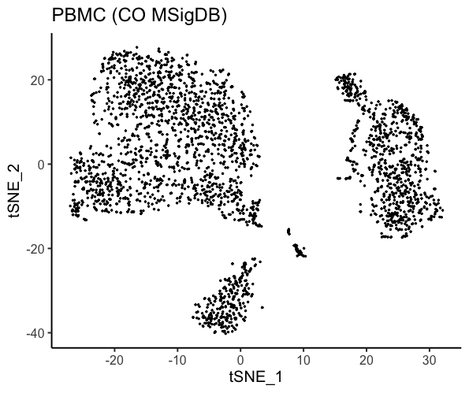

```r
dataframe2D <- as.data.frame(reducedDim(pbmcs$CM, "TSNE"))
plot_dataframe2D(dataframe2D = dataframe2D) +
  ggplot2::labs(title = "PBMC (CO MSigDB)", x = "tSNE_1", y = "tSNE_2") +
  ggplot2::theme_classic(base_size = 15)
```

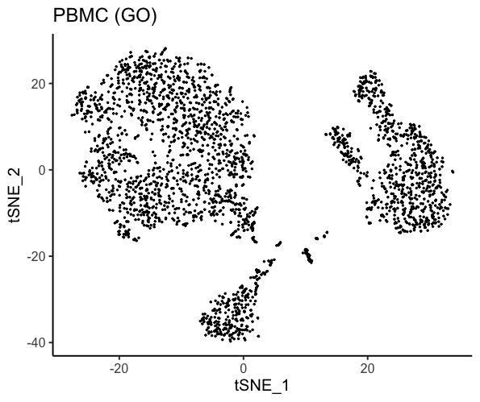

```r
dataframe2D <- as.data.frame(reducedDim(pbmcs$GO, "TSNE"))
plot_dataframe2D(dataframe2D = dataframe2D) +
  ggplot2::labs(title = "PBMC (GO)", x = "tSNE_1", y = "tSNE_2") +
  ggplot2::theme_classic(base_size = 15)
```

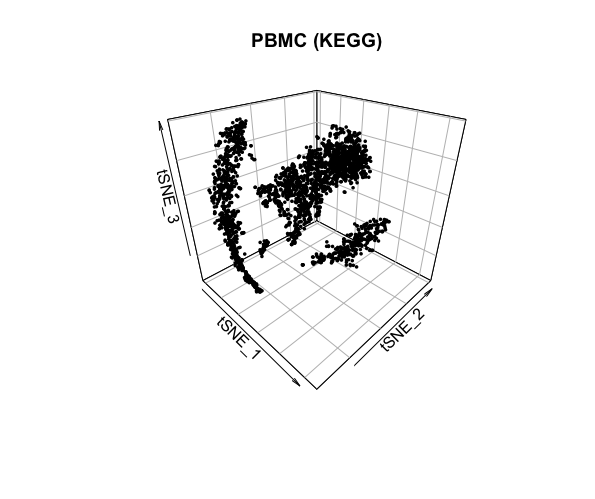

```r
dataframe3D <- as.data.frame(reducedDim(pbmcs$KG, "TSNE"))
plot_dataframe3D(dataframe3D = dataframe3D,
                 theta = 45, phi = 30, title = "PBMC (KEGG)",
                 xlabel = "tSNE_1", ylabel = "tSNE_2", zlabel = "tSNE_3")
```

## 5.6 Cluster cells

### 5.6.1 Use Seurat functions

To date (December, 2021), one of the most useful clustering methods in scRNA-seq data analysis is a combination of a community detection algorithm and graph-based unsupervised clustering, developed in Seurat package.

In this tutorial, our strategy is as follows:

1. convert SingleCellExperiment objects into Seurat objects (note that `rowData()` and `colData()` must have data),
2. perform `ScaleData()`, `RunPCA()`, `FindNeighbors()`, and `FindClusters()`,
3. convert Seurat objects into temporal SingleCellExperiment objects `temp`,
4. add `colData(temp)$seurat_clusters` into `colData(sce)$seurat_clusters`.

```r
resolutions <- c(0.20, 0.18, 0.30)
ds <- list(seq_len(30), seq_len(30), seq_len(30))
for(i in seq_len(length(pbmcs))){
  pbmc_surt <- Seurat::as.Seurat(pbmcs[[i]], counts = "counts", data = "counts")
  pbmc_surt[["SSM"]] <- Seurat::CreateAssayObject(
    counts = as.matrix(assay(pbmcs[[i]], "counts")))
  Seurat::DefaultAssay(pbmc_surt) <- "SSM"
  pbmc_surt <- Seurat::ScaleData(pbmc_surt, features = rownames(pbmc_surt))
  pbmc_surt <- Seurat::RunPCA(pbmc_surt, features = rownames(pbmc_surt))
  pbmc_surt <- Seurat::FindNeighbors(pbmc_surt, reduction = "pca", dims = ds[[i]])
  pbmc_surt <- Seurat::FindClusters(pbmc_surt, resolution = resolutions[i])
  pbmc_temp <- Seurat::as.SingleCellExperiment(pbmc_surt)
  colData(pbmcs[[i]])$seurat_clusters <- colData(pbmc_temp)$seurat_clusters
}
```

The results can be visualized by ASURAT functions `plot_dataframe2D()` or `plot_dataframe3D()`. See `?plot_dataframe2D` and `?plot_dataframe3D` for details.

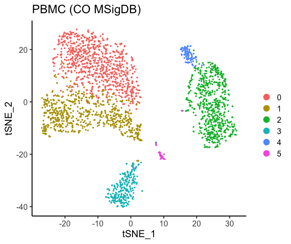

```r
labels <- colData(pbmcs$CM)$seurat_clusters
dataframe2D <- as.data.frame(reducedDim(pbmcs$CM, "TSNE"))
plot_dataframe2D(dataframe2D = dataframe2D, labels = labels, colors = NULL) +
  ggplot2::labs(title = "PBMC (CO MSigDB)", x = "tSNE_1", y = "tSNE_2", color = "") +
  ggplot2::theme_classic(base_size = 15) +
  ggplot2::guides(colour = ggplot2::guide_legend(override.aes = list(size = 4)))
```

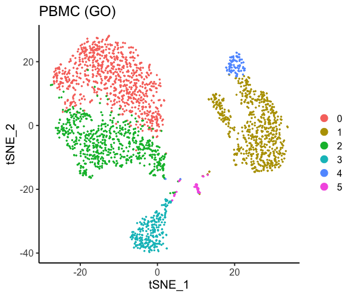

```r
labels <- colData(pbmcs$GO)$seurat_clusters
dataframe2D <- as.data.frame(reducedDim(pbmcs$GO, "TSNE"))
plot_dataframe2D(dataframe2D = dataframe2D, labels = labels, colors = NULL) +
  ggplot2::labs(title = "PBMC (GO)", x = "tSNE_1", y = "tSNE_2", color = "") +
  ggplot2::theme_classic(base_size = 15) +
  ggplot2::guides(colour = ggplot2::guide_legend(override.aes = list(size = 4)))
```

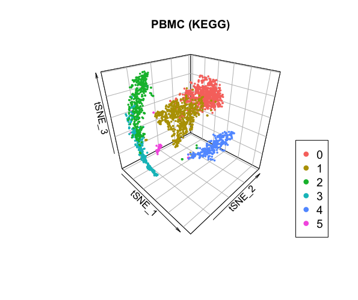

```r
labels <- colData(pbmcs$KG)$seurat_clusters
dataframe3D <- as.data.frame(reducedDim(pbmcs$KG, "TSNE")[, seq_len(3)])
plot_dataframe3D(dataframe3D = dataframe3D, labels = labels, colors = NULL,
                 theta = 45, phi = 30, title = "PBMC (KEGG)",
                 xlabel = "tSNE_1", ylabel = "tSNE_2", zlabel = "tSNE_3")
```

### 5.6.2 Cell cycle inference using Seurat functions

If there is gene expression data in `altExp(sce)`, one can infer cell cycle phases by using Seurat functions in the similar manner as above.

```r
pbmc_surt <- Seurat::as.Seurat(pbmcs$CM, counts = "counts", data = "counts")
pbmc_surt[["GEM"]] <- Seurat::CreateAssayObject(
  counts = as.matrix(assay(altExp(pbmcs$CM), "counts")))
Seurat::DefaultAssay(pbmc_surt) <- "GEM"
pbmc_surt <- Seurat::ScaleData(pbmc_surt, features = rownames(pbmc_surt))
pbmc_surt <- Seurat::RunPCA(pbmc_surt, features = rownames(pbmc_surt))
pbmc_surt <- Seurat::CellCycleScoring(pbmc_surt,
                                      s.features = Seurat::cc.genes$s.genes,
                                      g2m.features = Seurat::cc.genes$g2m.genes)
pbmc_temp <- Seurat::as.SingleCellExperiment(pbmc_surt)
colData(pbmcs$CM)$Phase <- colData(pbmc_temp)$Phase
```

## 5.7 Investigate significant signs

Significant signs are analogous to differentially expressed genes but bear biological meanings. Note that naïve usages of statistical tests should be avoided because the row vectors of SSMs are centered.

Instead, ASURAT function `compute_sepI_all()` computes separation indices for each cluster against the others. Briefly, a separation index “sepI”, ranging from -1 to 1, is a nonparametric measure of significance of a given sign score for a given subpopulation. The larger (resp. smaller) sepI is, the more reliable the sign is as a positive (resp. negative) marker for the cluster.

The arguments are

- `sce`: SingleCellExperiment object,
- `labels`: a vector of labels of all the samples, and
- `nrand_samples`: an integer for the number of samples used for random sampling, which samples at least one sample per cluster.

```r
for(i in seq_len(length(pbmcs))){
  set.seed(1)
  labels <- colData(pbmcs[[i]])$seurat_clusters
  pbmcs[[i]] <- compute_sepI_all(sce = pbmcs[[i]], labels = labels,
                                 nrand_samples = 100)
}
```

The results are stored in `metadata(sce)$marker_signs`.

When computing separation indices between given clusters, e.g., cluster 1 versus clusters 2 and 3, use an ASURAT function `compute_sepI_clusters()`. See `?compute_sepI_clusters` for details.

## 5.8 Investigate significant genes

### 5.8.1 Use Seurat function

To date (December, 2021), one of the most useful methods of multiple statistical tests in scRNA-seq data analysis is to use a Seurat function `FindAllMarkers()`.

If there is gene expression data in `altExp(sce)`, one can investigate differentially expressed genes by using Seurat functions in the similar manner as described before.

```r
set.seed(1)
pbmc_surt <- Seurat::as.Seurat(pbmcs$CM, counts = "counts", data = "counts")
pbmc_surt[["GEM"]] <- Seurat::CreateAssayObject(
  counts = as.matrix(assay(altExp(pbmcs$CM), "counts")))
Seurat::DefaultAssay(pbmc_surt) <- "GEM"
pbmc_surt <- Seurat::SetIdent(pbmc_surt, value = "seurat_clusters")
res <- Seurat::FindAllMarkers(pbmc_surt, only.pos = TRUE,
                              min.pct = 0.25, logfc.threshold = 0.25)
metadata(pbmcs$CM)$marker_genes$all <- res
```

ASURAT function `plog_violin()` shows violin plots showing gene expression distributions. See `?plot_violin` for details.

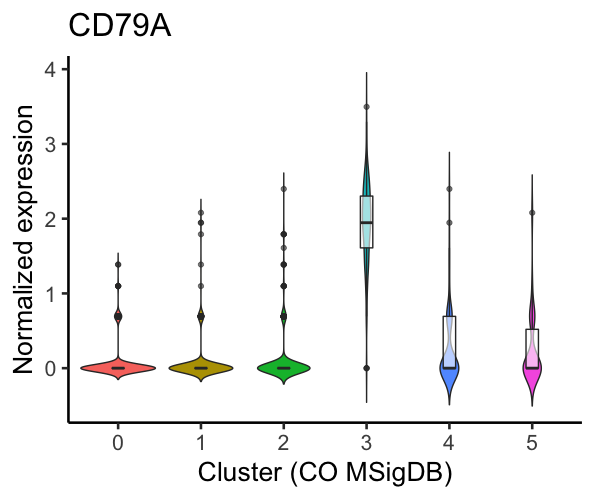

```r
vname <- "CD79A"
expr_sub <- altExp(pbmcs$CM, "logcounts")
expr_sub <- expr_sub[rownames(expr_sub) == vname]
labels <- colData(pbmcs$CM)$seurat_clusters
dataframe1D <- as.data.frame(t(assay(expr_sub, "counts")))
plot_violin(dataframe1D = dataframe1D, labels = labels, colors = NULL) +
  ggplot2::labs(title = vname, x = "Cluster (CO MSigDB)",
                y = "Normalized expression") +
  ggplot2::theme_classic(base_size = 20) +
  ggplot2::theme(legend.position = "none")
```

# 6 Multifaceted sign analysis

Simultaneously analyze multiple sign-by-sample matrices, which helps us characterize individual samples (cells) from multiple biological aspects.

First, manually curate significant signs by setting keywords, followed by selecting top significant signs and genes for the clustering results with respect to separation index and p-value, respectively.

```r
# Significant signs
marker_signs <- list()
keywords <- c("LIMB|limb|OENOCYTE|oenocyte", "GO:0002221-S|GO:0035425-S",
              "path:hsa00565-S|path:hsa00564-S")
for(i in seq_len(length(pbmcs))){
  marker_signs[[i]] <- metadata(pbmcs[[i]])$marker_signs$all
  marker_signs[[i]] <- marker_signs[[i]][!grepl(keywords[i],
                                                marker_signs[[i]]$Description), ]
  marker_signs[[i]] <- dplyr::group_by(marker_signs[[i]], Ident_1)
  marker_signs[[i]] <- dplyr::slice_max(marker_signs[[i]], sepI, n = 1)
  marker_signs[[i]] <- dplyr::slice_min(marker_signs[[i]], Rank, n = 1)
}
# Significant genes
marker_genes_CM <- metadata(pbmcs$CM)$marker_genes$all
marker_genes_CM <- dplyr::group_by(marker_genes_CM, cluster)
marker_genes_CM <- dplyr::slice_min(marker_genes_CM, p_val_adj, n = 5)
marker_genes_CM <- dplyr::slice_max(marker_genes_CM, avg_log2FC, n = 1)
```

ASURAT function `plot_multiheatmaps()` shows heatmaps (ComplexHeatmap object) of sign scores and gene expression levels (if there are), where rows and columns stand for sign (or gene) and sample (cell), respectively. See `?plot_multiheatmaps` for details.

The arguments are prepared as follows:

```r
# ssm_list
pbmcs_sub <- list() ; ssm_list <- list()
for(i in seq_len(length(pbmcs))){
  pbmcs_sub[[i]] <- pbmcs[[i]][rownames(pbmcs[[i]]) %in% marker_signs[[i]]$SignID, ]
  ssm_list[[i]] <- assay(pbmcs_sub[[i]], "counts")
}
names(ssm_list) <- c("SSM_COMSig", "SSM_GO", "SSM_KEGG")
# gem_list
expr_sub <- altExp(pbmcs$CM, "logcounts")
expr_sub <- expr_sub[rownames(expr_sub) %in% marker_genes_CM$gene]
gem_list <- list(GeneExpr = assay(expr_sub, "counts"))
# ssmlabel_list
labels <- list() ; ssmlabel_list <- list()
for(i in seq_len(length(pbmcs))){
  labels[[i]] <- data.frame(label = colData(pbmcs_sub[[i]])$seurat_clusters)
  labels[[i]]$color <- NA
  ssmlabel_list[[i]] <- labels[[i]]
}
names(ssmlabel_list) <- c("Label_COMSig", "Label_GO", "Label_KEGG")
# gemlabel_list
label_CC <- data.frame(label = colData(pbmcs$CM)$Phase, color = NA)
gemlabel_list <- list(CellCycle = label_CC)
```

Show heatmaps for the selected signs and genes.

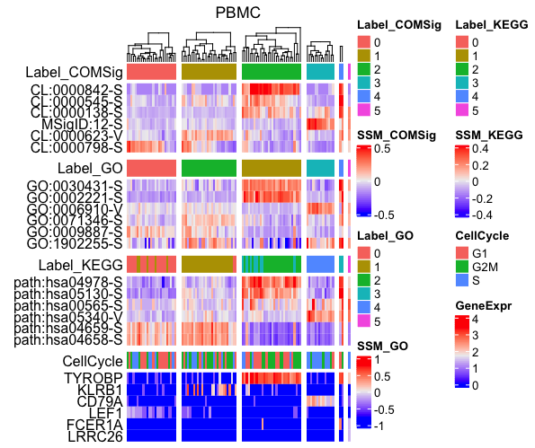

```r
set.seed(1)
plot_multiheatmaps(ssm_list = ssm_list, gem_list = gem_list,
                   ssmlabel_list = ssmlabel_list, gemlabel_list = gemlabel_list,
                   nrand_samples = 100, show_row_names = TRUE, title = "PBMC")
```

ASURAT function `plot_violin()` shows violin plots showing sign score distributions. See `?plot_violin` for details.

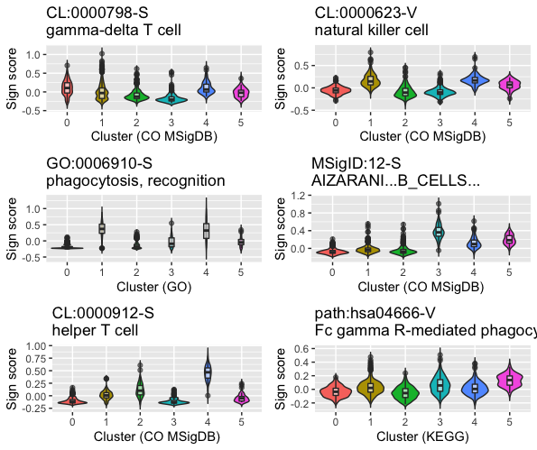

```r
vlist <- list(c("CM", "CL:0000798-S", "gamma-delta T cell"),
              c("CM", "CL:0000623-V", "natural killer cell"),
              c("GO", "GO:0006910-S", "phagocytosis, recognition"),
              c("CM", "MSigID:12-S", "AIZARANI...B_CELLS..."),
              c("CM", "CL:0000912-S", "helper T cell"),
              c("KG", "path:hsa04666-V", "Fc gamma R-mediated phagocytosis"))
xlabels <- list(CM = "Cluster (CO MSigDB)", GO = "Cluster (GO)", KG = "Cluster (KEGG)")
p <- list()
for(i in seq_len(length(vlist))){
  ind <- which(rownames(pbmcs[[vlist[[i]][1]]]) == vlist[[i]][2])
  pbmc_sub <- pbmcs[[vlist[[i]][1]]][ind, ]
  labels <- colData(pbmc_sub)$seurat_clusters
  dataframe1D <- as.data.frame(t(assay(pbmc_sub, "counts")))
  p[[i]] <- plot_violin(dataframe1D = dataframe1D, labels = labels) +
    ggplot2::labs(title = paste0(vlist[[i]][2], "\n", vlist[[i]][3]),
                  x = xlabels[[vlist[[i]][1]]], y = "Sign score", fill = "Cluster") +
    ggplot2::theme(legend.position = "none")
}
gridExtra::grid.arrange(p[[1]], p[[2]], p[[3]], p[[4]], p[[5]], p[[6]])
```